Created by: Marco Hafid - 22-620-546 Matus Kubla - 23-604-382

Describe the dataset and the classification problem: We would like to create models that can predict if a person suffered from heart failure or not, for this we are using a dataset with 11 predictor variables (+ the target variable) and 918 observations. We will use 4 different classification models - Linear Discriminant Analysis (LDA), Quadratic Discriminant Analysis (QDA), Naive Bayes and Logistic Regression- and compare their performance on the following metrics:

- Accuracy: Proportion of correct predictions made overall Accuracy = number of correct predictions / total number of predictions
- Precision: Proportion of true positive predictions in the total predicted positives Precision = True positives / (True positives + False positives)
- Recall (sensitivity): Proportion of actual positives correctly identified by the model Recall = True positives / (True positives + False negatives)

While there is no single perfect metric to assess the performance of a model, the nature of our classification task - predicting heart disease based on health data of patients - makes false negatives (failing to identify heart disease) particularly costlier than say, false positives (“false alarms”). Clearly then, recall is the most relevant metric in our case, as the primary goal would be to identify as many of the patients with heart disease as possible (even at a cost of a small amount of false alarms), rather than being precise but failing to identify and help impacted patients.

The initial dataset contains the following variables:

“Age: age of the patient [years]

Sex: sex of the patient [M: Male, F: Female] ChestPainType: chest pain type [TA: Typical Angina, ATA: Atypical Angina, NAP: Non-Anginal Pain, ASY: Asymptomatic]

RestingBP: resting blood pressure [mm Hg]

Cholesterol: serum cholesterol [mm/dl]

FastingBS: fasting blood sugar [1: if FastingBS > 120 mg/dl, 0: otherwise]

RestingECG: resting electrocardiogram results [Normal: Normal, ST: having ST-T wave abnormality (T wave inversions and/or ST elevation or depression of > 0.05 mV), LVH: showing probable or definite left ventricular hypertrophy by Estes’ criteria]

MaxHR: maximum heart rate achieved [Numeric value between 60 and 202]

ExerciseAngina: exercise-induced angina [Y: Yes, N: No]

Oldpeak: oldpeak = ST [Numeric value measured in depression]

ST_Slope: the slope of the peak exercise ST segment [Up: upsloping, Flat: flat, Down: downsloping]

HeartDisease: output class [1: heart disease, 0: Normal]”

(source: https://www.kaggle.com/datasets/fedesoriano/heart-failure-prediction/data)

Importing the libraries

Importing data

```r
# Set the working directory and import the dataset
setwd(dirname(rstudioapi::getActiveDocumentContext()$path))
heart_failure <- read.csv("heart.csv")
# Show a summary of the variables and print the first few rows of the dataframe
summary(heart_failure)
```

```
##       Age            Sex            ChestPainType        RestingBP
##  Min.   :28.00   Length:918         Length:918         Min.   :  0.0
##  1st Qu.:47.00   Class :character   Class :character   1st Qu.:120.0
##  Median :54.00   Mode  :character   Mode  :character   Median :130.0
##  Mean   :53.51                                         Mean   :132.4
##  3rd Qu.:60.00                                         3rd Qu.:140.0
##  Max.   :77.00                                         Max.   :200.0
##   Cholesterol      FastingBS       RestingECG            MaxHR
##  Min.   :  0.0   Min.   :0.0000   Length:918         Min.   : 60.0
##  1st Qu.:173.2   1st Qu.:0.0000   Class :character   1st Qu.:120.0
##  Median :223.0   Median :0.0000   Mode  :character   Median :138.0
##  Mean   :198.8   Mean   :0.2331                      Mean   :136.8
##  3rd Qu.:267.0   3rd Qu.:0.0000                      3rd Qu.:156.0
##  Max.   :603.0   Max.   :1.0000                      Max.   :202.0
##  ExerciseAngina        Oldpeak          ST_Slope          HeartDisease
##  Length:918         Min.   :-2.6000   Length:918         Min.   :0.0000
##  Class :character   1st Qu.: 0.0000   Class :character   1st Qu.:0.0000
##  Mode  :character   Median : 0.6000   Mode  :character   Median :1.0000
##                     Mean   : 0.8874                      Mean   :0.5534
##                     3rd Qu.: 1.5000                      3rd Qu.:1.0000
##                     Max.   : 6.2000                      Max.   :1.0000
```

```r
#print(heart_failure)
```

There are some issues with the data, such as 172 observations having a cholesterol value of 0, which is not possible, these will be removed. Also some of the categorical variables need to be transformed from text to categories.

The categories were transformed to the following: Sex: sex of the patient [M: 0, F: 1] ChestPainType: chest pain type [TA: 0, ATA: 1, NAP:2 , ASY: 3] ExerciseAngina: exercise-induced angina [Y: 1, N: 0] ST_Slope: the slope of the peak exercise ST segment [Up: 0, Flat: 1, Down: 2] RestingECG: resting electrocardiogram results [Normal: 0, ST: 1, LVH: 2]

Feature engineering and cleaning the data

```r
# Remove the observations where the cholesterol level is exactly 0
heart_failure <- heart_failure[heart_failure$Cholesterol != 0, ]

# Mapping for 'ChestPainType'
chest_pain_mapping <- c("TA" = 0, "ATA" = 1, "NAP" = 2, "ASY" = 3)

# Mapping for 'ST_Slope'
slope_mapping <- c("Up" = 0, "Flat" = 1, "Down" = 2)

# Mapping for 'RestingECG'
resting_ecg_mapping <- c("Normal" = 0, "ST" = 1, "LVH" = 2)

# Apply transformations to the dataframe
heart_failure <- heart_failure %>%
  mutate(Sex = factor(Sex, levels = c("M", "F"), labels = c(0, 1))) %>%
  mutate(ChestPainType = factor(ChestPainType, levels = names(chest_pain_mapping),
                                labels = chest_pain_mapping)) %>%
  mutate(ExerciseAngina = factor(ExerciseAngina, levels = c("N", "Y"),
                                 labels = c(0, 1))) %>%
  mutate(ST_Slope = factor(ST_Slope, levels = names(slope_mapping),
                           labels = slope_mapping)) %>%
  mutate(RestingECG = factor(RestingECG, levels = names(resting_ecg_mapping),
                             labels = resting_ecg_mapping))
```

In the following steps we are investigating some characteristics of the variables, such as correlation or their significance in a random forest model to decide which variables to keep or discard for the classification models.

```r
# Creating a correlation matrix
numeric_columns <- sapply(heart_failure, is.numeric)
correlation_matrix <- cor(heart_failure[,numeric_columns])
correlation_matrix
```

```
##                      Age   RestingBP Cholesterol   FastingBS       MaxHR
## Age           1.00000000  0.25986472  0.05875824  0.24133789 -0.38211212
## RestingBP     0.25986472  1.00000000  0.09593929  0.17376511 -0.12577393
## Cholesterol   0.05875824  0.09593929  1.00000000  0.05401235 -0.01985579
## FastingBS     0.24133789  0.17376511  0.05401235  1.00000000 -0.10270984
## MaxHR        -0.38211212 -0.12577393 -0.01985579 -0.10270984  1.00000000
## Oldpeak       0.28600628  0.19857506  0.05848813  0.05556829 -0.25953263
## HeartDisease  0.29861668  0.17324158  0.10386560  0.16059410 -0.37721219
##                  Oldpeak HeartDisease
## Age           0.28600628    0.2986167
## RestingBP     0.19857506    0.1732416
## Cholesterol   0.05848813    0.1038656
## FastingBS     0.05556829    0.1605941
## MaxHR        -0.25953263   -0.3772122
## Oldpeak       1.00000000    0.4956963
## HeartDisease  0.49569625    1.0000000
```

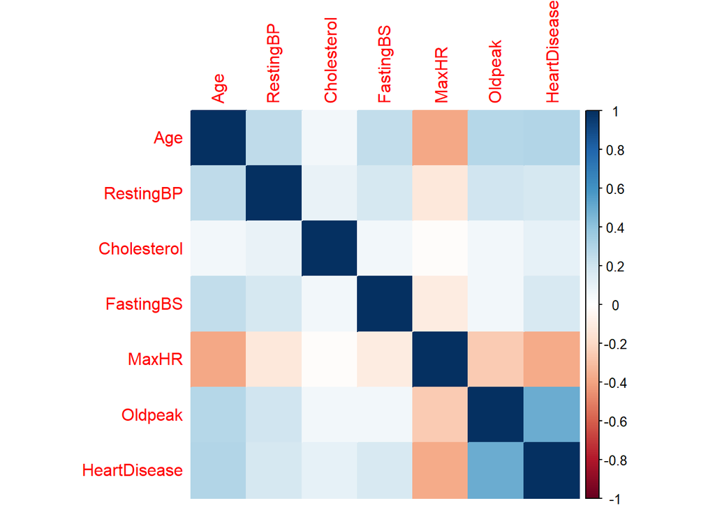

```r
# Plotting the correlation matrix
corrplot(correlation_matrix, method = "color")
```

We created a Random Forest model to determine which variables to keep and which ones to discard. We calculated and plotted the variable importance values, where we decided to discard FastingBS, RestingECG and Sex due to these variables not being too significant. This leaves our final dataset with 8 predictor variables and 746 observations.

```r
# Create the Random Forest model
rf_model <- randomForest(HeartDisease ~ ., data = heart_failure, ntree = 100, mtry=4,
                         type = "classification")
# Print variable importance
print("Variable Importance:")
```

```
## [1] "Variable Importance:"
```

```r
print(round(importance(rf_model), 2))
```

```
##                IncNodePurity
## Age                    12.31
## Sex                     6.30
## ChestPainType          18.80
## RestingBP              11.59
## Cholesterol            10.81
## FastingBS               1.32
## RestingECG              4.90
## MaxHR                  15.87
## ExerciseAngina         18.77
## Oldpeak                20.12
## ST_Slope               52.49
```

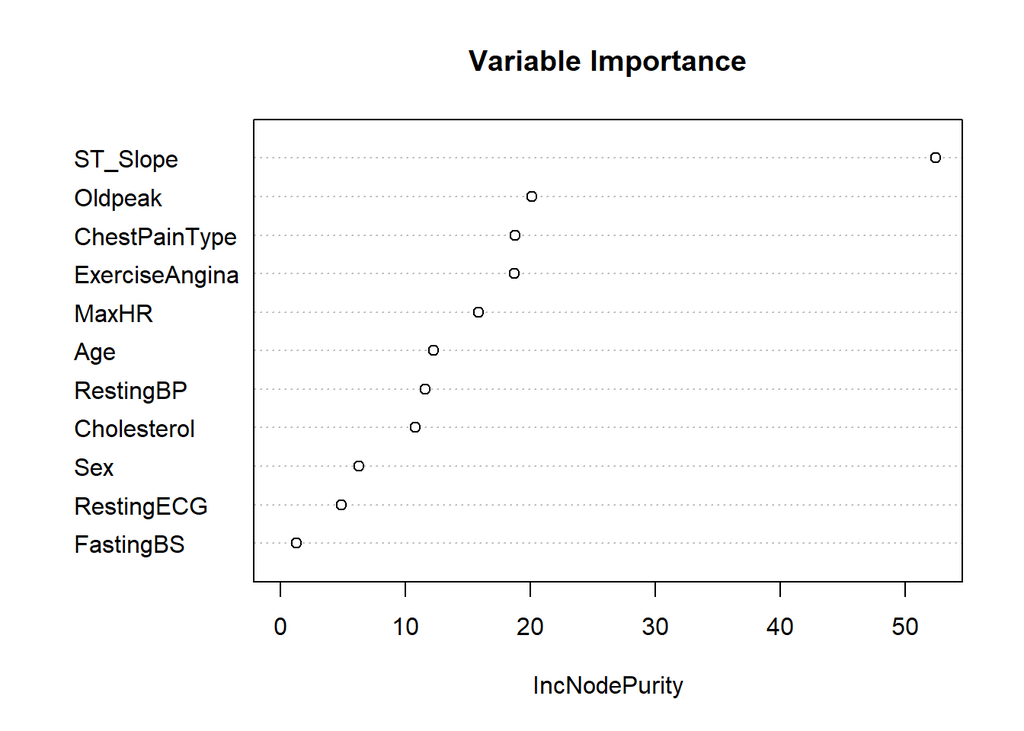

```r
# Plot variable importance
varImpPlot(rf_model, main = "Variable Importance")
```

```r
# Remove the variables not deemed significant by Random Forest
heart_failure <- heart_failure[, !colnames(heart_failure) %in%
                                 c("Sex", "FastingBS", "RestingECG")]
```

```r
# Summarise and print the final df
summary(heart_failure)
```

```
##       Age        ChestPainType   RestingBP    Cholesterol        MaxHR
##  Min.   :28.00   0: 41         Min.   : 92   Min.   : 85.0   Min.   : 69.0
##  1st Qu.:46.00   1:166         1st Qu.:120   1st Qu.:207.2   1st Qu.:122.0
##  Median :54.00   2:169         Median :130   Median :237.0   Median :140.0
##  Mean   :52.88   3:370         Mean   :133   Mean   :244.6   Mean   :140.2
##  3rd Qu.:59.00                 3rd Qu.:140   3rd Qu.:275.0   3rd Qu.:160.0
##  Max.   :77.00                 Max.   :200   Max.   :603.0   Max.   :202.0
##  ExerciseAngina    Oldpeak        ST_Slope  HeartDisease
##  0:459          Min.   :-0.1000   0:349    Min.   :0.0000
##  1:287          1st Qu.: 0.0000   1:354    1st Qu.:0.0000
##                 Median : 0.5000   2: 43    Median :0.0000
##                 Mean   : 0.9016            Mean   :0.4772
##                 3rd Qu.: 1.5000            3rd Qu.:1.0000
##                 Max.   : 6.2000            Max.   :1.0000
```

```r
#print(head(heart_failure, 10))
```

We randomly split the data into a training and test subset with a 75:25 ratio.

```r
set.seed(123)

# Generate random indices for splitting
indices <- sample(seq_len(nrow(heart_failure)), 0.75 * nrow(heart_failure))

# Create training and test sets for features (X)
X_train <- heart_failure[indices, -which(names(heart_failure) == "HeartDisease")]
X_test <- heart_failure[-indices, -which(names(heart_failure) == "HeartDisease")]

# Create training and test sets for the target variable (Y)
Y_train <- heart_failure$HeartDisease[indices]
Y_test <- heart_failure$HeartDisease[-indices]

# Convert Y to factors
Y_train <- as.factor(Y_train)
Y_test <- as.factor(Y_test)
```

The first classification method we used is Linear Discriminant Analysis (LDA), which is based on finding a linear combination of features that best separates classes of objects. This resulting combination can hence later be used as a linear classifier.

As a method, LDA relies on several key assumptions e.g:

- Predictor variables are assumed to be normally distributed
- Independence of Predictors
- Equal Covariance Matrix for both of the classes.

```r
# Initialize the LDA model
lda_model <- lda(Y_train ~ ., data = X_train)

# Make predictions on the testing set
y_pred <- predict(lda_model, newdata = X_test)$class

# Get confusion matrix
conf_matrix <- table(Actual = Y_test, Predicted = y_pred)
print("Confusion Matrix:")
```

```
## [1] "Confusion Matrix:"
```

```r
print(conf_matrix)
```

```
##       Predicted
## Actual  0  1
##      0 82 11
##      1 15 79
```

```r
# Get classification report
class_report <- confusionMatrix(conf_matrix)


# Get model's performance
cat("\nAccuracy:", class_report$overall['Accuracy'], "\n")
```

```
##
## Accuracy: 0.8609626
```

```r
cat("Precision:", class_report$byClass['Pos Pred Value'], "\n")
```

```
## Precision: 0.8817204
```

```r
cat("Recall (Sensitivity):", class_report$byClass['Sensitivity'], "\n")
```

```
## Recall (Sensitivity): 0.8453608
```

```r
cat("Specificity", class_report$byClass['Specificity'], "\n")
```

```
## Specificity 0.8777778
```

To supplement the performance evaluation of our classifiers, we use the ROC (Receiver Operating Characteristic) Curve along with the AUC (Area under the Curve) measure. The ROC curve plots the True Positive Rate (sensitivity or recall) against the False Positive Rate (1 - specificity) at various threshold settings, allowing to visually assess the trade-offs between detecting true positives and avoiding false positives. The Area Under the ROC Curve (AUC) is a scalar value that efficiently summarizes the entire ROC curve into a single metric, representing the classifier’s ability to distinguish between the positive and negative classes, regardless of the level of the probability threshold. The higher the AUC, the higher the model’s discriminative ability - capability to correctly distinguish between the different classes in the dataset. An AUC of 1 would hence indicate perfect classification, while an AUC of 0.5 suggests performance no different to random guessing.

The use of the ROC and AUC for performance allows us to get a more comprehensive evaluation of our model’s discriminative power, without reliance on a specific decision threshold, whose impact is directly reflected in the curve: Moving towards the bottom left corner relates to increasing the threshold, which decreases sensitivity, as the threshold for predicting a positive class (1 – disease) is higher. Conversely, moving towards the top right of the curve implies lowering the threshold, which is reflected in a higher sensitivity, as a lower threshold is needed for a positive class to be assigned.

```r
y_pred_prob <- predict(lda_model, newdata = X_test, type = "response")$posterior[,2]

# Calculate AUC
roc_result <- roc(Y_test, y_pred_prob)
```

```r
auc_value <- auc(roc_result)

# Print AUC
cat("AUC (Area Under the ROC Curve):", auc_value, "\n")
```

```
## AUC (Area Under the ROC Curve): 0.9200412
```

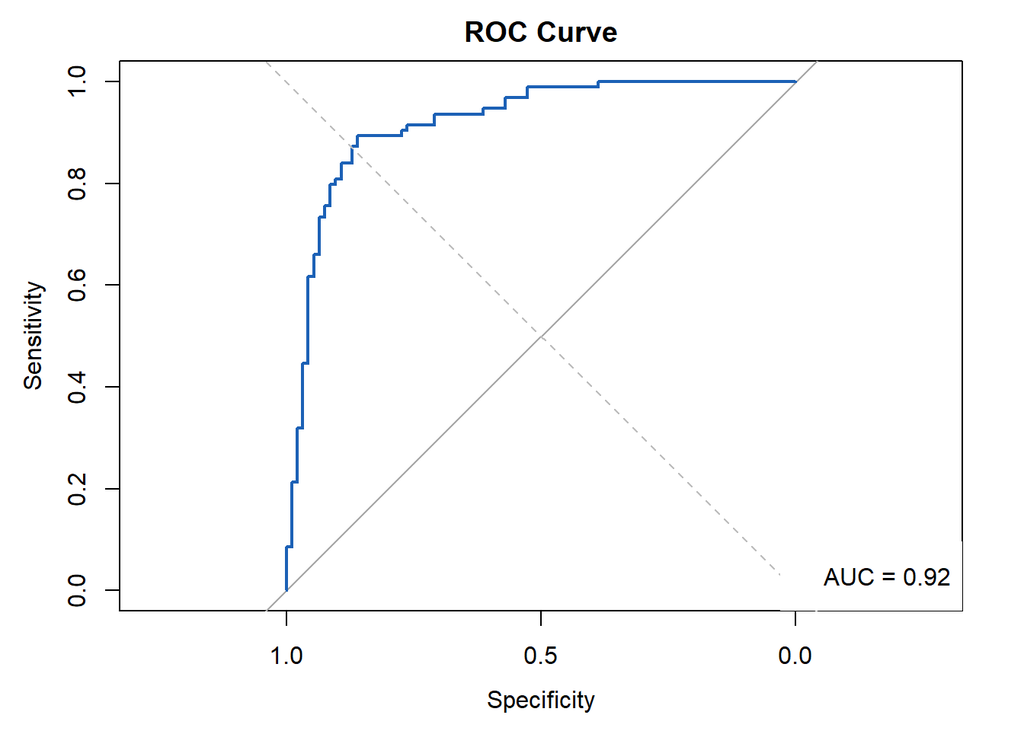

```r
plot(roc_result, main="ROC Curve", col="#1c61b6", lwd=2)
abline(a=0, b=1, lty=2, col="gray")
# Adds a diagonal dashed line representing a no-discrimination classifier

# Optionally, you can add the AUC value to the plot
auc_value <- auc(roc_result)
legend("bottomright", legend=paste("AUC =", round(auc_value, 3)), box.lty=0)
```

We now consider and plot the direct interrelation between our model’s sensitivity and specific threshold. Clearly, the relationship between the two needs to be inverse, in that high threshold values make it “more difficult” for an observation to be classified as positive (i.e.a patient has heart disease). This analysis also allows us to find alternative “optimal” sensitivity values of the model by adapting the threshold values so that the sum of the sensitivity and specificity of the model is maximized. This is in contrast with the values obtained in the first part of our analysis, which were evaluated at the benchmark threshold level of 0.5 As sensitivity is the key metric of interest in the case of heart disease classification, this analysis allows us to visualize, consider, and select potentially better suited threshold levels that would help increase the performance of our classifier.

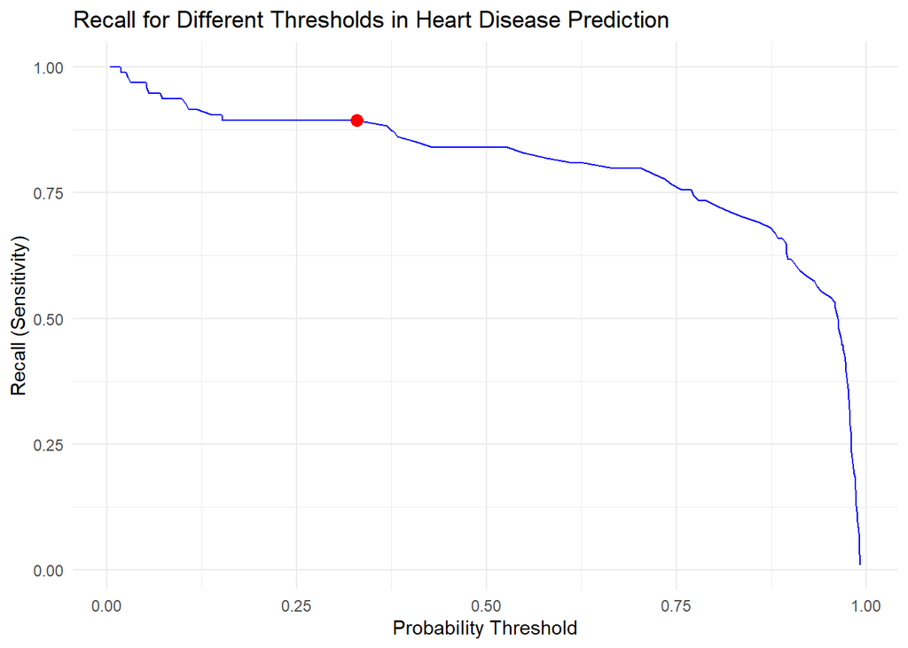

```r
# Plotting model sensitivity depending on probability threshold
# Create a data frame for plotting
recall_data <- data.frame(
  Threshold = roc_result$thresholds,
  Recall = roc_result$sensitivities
)

# Subset to only include thresholds between 0 and 1
recall_data <- subset(recall_data, Threshold >= 0 & Threshold <= 1)

# Find the optimal index and threshold
optimal_index <- which.max(roc_result$sensitivities + roc_result$specificities - 1)
optimal_threshold <- roc_result$thresholds[optimal_index]
optimal_recall <- roc_result$sensitivities[optimal_index]


# Plotting recall against probability threshold levels
ggplot(recall_data, aes(x = Threshold, y = Recall)) +
  geom_line(color = "blue") +
  geom_point(aes(x = optimal_threshold, y = optimal_recall), color = "red", size = 3) +
  labs(
    title = "Recall for Different Thresholds in Heart Disease Prediction",
    x = "Probability Threshold",
    y = "Recall (Sensitivity)"
  ) +
  theme_minimal()
```

```r
# Find the optimal index and corresponding threshold, sensitivity, and specificity
optimal_index <- which.max(roc_result$sensitivities + roc_result$specificities - 1)
optimal_threshold <- roc_result$thresholds[optimal_index]
optimal_sensitivity <- roc_result$sensitivities[optimal_index]
optimal_specificity <- roc_result$specificities[optimal_index]

# Print out the optimal coordinates
cat("Optimal Threshold:", optimal_threshold, "\n")
```

```
## Optimal Threshold: 0.3288703
```

```r
cat("Optimal Sensitivity (Recall):", optimal_sensitivity, "\n")
```

```
## Optimal Sensitivity (Recall): 0.893617
```

```r
cat("Optimal Specificity:", optimal_specificity, "\n")
```

```
## Optimal Specificity: 0.8602151
```

Quadratic Discriminant Analysis (QDA) is a classification method that extends Linear Discriminant Analysis (LDA) by allowing for different covariance matrices for each class. It seeks to find quadratic decision boundaries, providing more flexibility than LDA when classes exhibit distinct covariances. QDA is based on the following key characteristics:

- Quadratic Decision Boundaries: In contrast to LDA’s linear decision boundaries, QDA allows for quadratic decision boundaries between classes. This flexibility enables QDA to model more complex relationships in the data, capturing non-linear patterns that may be present.
- Multivariate Normal Distribution: Similar to LDA, QDA assumes that predictor variables within each class follow a multivariate normal distribution. This assumption is fundamental for the estimation of parameters in the model.
- Independence of Predictors: QDA, like LDA, assumes the independence of predictor variables within each class.. This simplifying assumption aids in parameter estimation and prevents multicollinearity issues.

Class-Specific Covariance Matrices: Unlike LDA, QDA relaxes the assumption of a common covariance matrix for all classes. Instead, QDA allows for different covariance matrices for each class. This is particularly beneficial when dealing with datasets where different classes exhibit distinct variances and covariances.

```r
# Initialize the QDA model
qda_model <- qda(Y_train ~ ., data = X_train)

# Make predictions on the testing set
y_pred <- predict(qda_model, newdata = X_test)$class

# Get confusion matrix
conf_matrix <- table(Actual = Y_test, Predicted = y_pred)
print("Confusion Matrix:")
```

```
## [1] "Confusion Matrix:"
```

```r
print(conf_matrix)
```

```
##       Predicted
## Actual  0  1
##      0 80 13
##      1 14 80
```

```r
# Get classification report
class_report <- confusionMatrix(conf_matrix)

# Get model's performance
cat("\nAccuracy:", class_report$overall['Accuracy'], "\n")
```

```
##
## Accuracy: 0.855615
```

```r
cat("Precision:", class_report$byClass['Pos Pred Value'], "\n")
```

```
## Precision: 0.8602151
```

```r
cat("Recall (Sensitivity):", class_report$byClass['Sensitivity'], "\n")
```

```
## Recall (Sensitivity): 0.8510638
```

```r
cat("Specificity:", class_report$byClass['Specificity'], "\n")
```

```
## Specificity: 0.8602151
```

```r
y_pred_prob <- predict(qda_model, newdata = X_test, type = "response")$posterior[,2]

# Calculate AUC
roc_result <- roc(Y_test, y_pred_prob)
```

```r
auc_value <- auc(roc_result)

# Print AUC
cat("AUC (Area Under the ROC Curve):", auc_value, "\n")
```

```
## AUC (Area Under the ROC Curve): 0.8882407
```

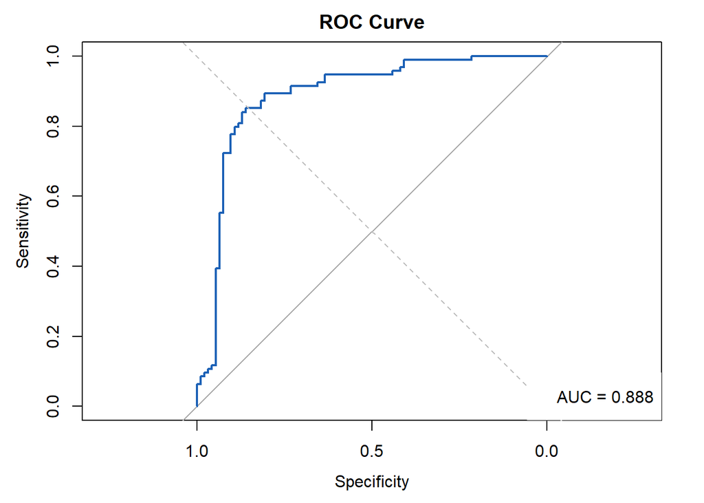

```r
plot(roc_result, main="ROC Curve", col="#1c61b6", lwd=2)
abline(a=0, b=1, lty=2, col="gray")
# Adds a diagonal dashed line representing a no-discrimination classifier

# Optionally, you can add the AUC value to the plot
auc_value <- auc(roc_result)
legend("bottomright", legend=paste("AUC =", round(auc_value, 3)), box.lty=0)
```

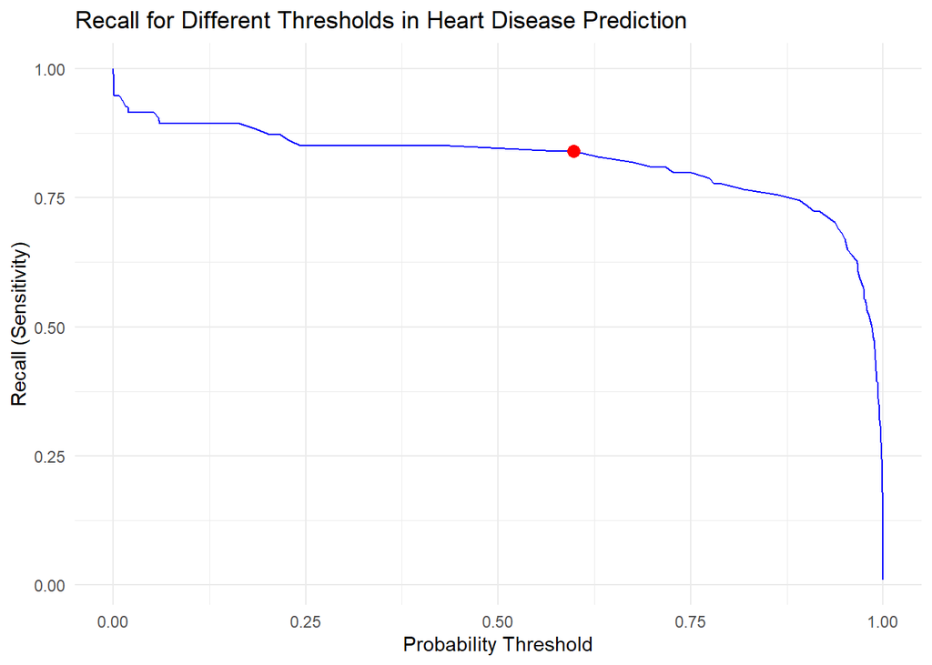

```r
# Plotting model sensitivity depending on probability threshold
# Create a data frame for plotting
recall_data <- data.frame(
  Threshold = roc_result$thresholds,
  Recall = roc_result$sensitivities
)

# Subset to only include thresholds between 0 and 1
recall_data <- subset(recall_data, Threshold >= 0 & Threshold <= 1)

# Find the optimal index and threshold
optimal_index <- which.max(roc_result$sensitivities + roc_result$specificities - 1)
optimal_threshold <- roc_result$thresholds[optimal_index]
optimal_recall <- roc_result$sensitivities[optimal_index]


# Plotting recall against probability threshold levels
ggplot(recall_data, aes(x = Threshold, y = Recall)) +
  geom_line(color = "blue") +
  geom_point(aes(x = optimal_threshold, y = optimal_recall), color = "red", size = 3) +
  labs(
    title = "Recall for Different Thresholds in Heart Disease Prediction",
    x = "Probability Threshold",
    y = "Recall (Sensitivity)"
  ) +
  theme_minimal()
```

```r
# Find the optimal index and corresponding threshold, sensitivity, and specificity
optimal_index <- which.max(roc_result$sensitivities + roc_result$specificities - 1)
optimal_threshold <- roc_result$thresholds[optimal_index]
optimal_sensitivity <- roc_result$sensitivities[optimal_index]
optimal_specificity <- roc_result$specificities[optimal_index]

# Print out the optimal coordinates
cat("Optimal Threshold:", optimal_threshold, "\n")
```

```
## Optimal Threshold: 0.5984044
```

```r
cat("Optimal Sensitivity (Recall):", optimal_sensitivity, "\n")
```

```
## Optimal Sensitivity (Recall): 0.8404255
```

```r
cat("Optimal Specificity:", optimal_specificity, "\n")
```

```
## Optimal Specificity: 0.8709677
```

Naive Bayes is a probabilistic machine learning algorithm based on Bayes’ theorem. It is particularly useful for classification tasks, especially in text classification and spam filtering. The “naive” part comes from the assumption of independence among features given the class label. Despite this simplifying assumption, Naive Bayes often performs well and is computationally efficient. It calculates the probability of a given instance belonging to each class and selects the class with the highest probability. Some key assumptions include:

- Conditional Independence
- Feature Distribution, it assumes each feature is independent across classes.

```r
# Create the Naive Bayes model
naive_bayes_model <- naiveBayes(X_train, Y_train)

# Use the model on the test dataset
Y_pred <- predict(naive_bayes_model, newdata = X_test)

# Get confusion matrix
conf_matrix <- table(Actual = Y_test, Predicted = Y_pred)
print("Confusion Matrix:")
```

```
## [1] "Confusion Matrix:"
```

```r
print(conf_matrix)
```

```
##       Predicted
## Actual  0  1
##      0 82 11
##      1 17 77
```

```r
# Get classification report
class_report <- confusionMatrix(conf_matrix)

# Get model's performance
cat("\nAccuracy:", class_report$overall['Accuracy'], "\n")
```

```
##
## Accuracy: 0.8502674
```

```r
cat("Precision:", class_report$byClass['Pos Pred Value'], "\n")
```

```
## Precision: 0.8817204
```

```r
cat("Recall (Sensitivity):", class_report$byClass['Sensitivity'], "\n")
```

```
## Recall (Sensitivity): 0.8282828
```

```r
cat("Specificity:", class_report$byClass['Specificity'], "\n")
```

```
## Specificity: 0.875
```

```r
y_pred_prob <- predict(naive_bayes_model, newdata = X_test, type="raw")[,2]

# Calculate AUC
roc_result <- roc(Y_test, y_pred_prob)
```

```r
auc_value <- auc(roc_result)

# Print AUC
cat("AUC (Area Under the ROC Curve):", auc_value, "\n")
```

```
## AUC (Area Under the ROC Curve): 0.9051704
```

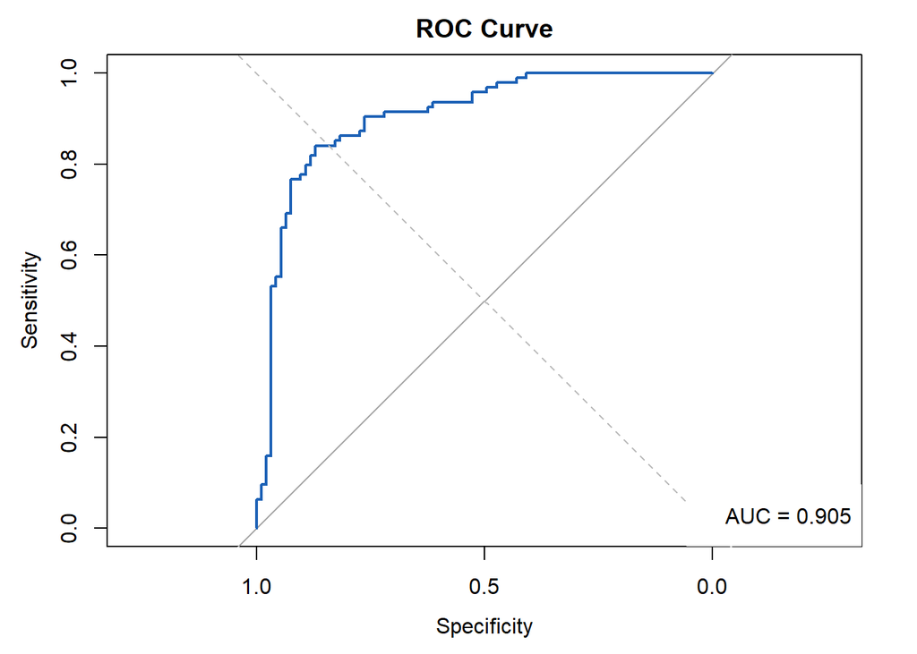

```r
plot(roc_result, main="ROC Curve", col="#1c61b6", lwd=2)
abline(a=0, b=1, lty=2, col="gray")
# Adds a diagonal dashed line representing a no-discrimination classifier

# Optionally, you can add the AUC value to the plot
auc_value <- auc(roc_result)
legend("bottomright", legend=paste("AUC =", round(auc_value, 3)), box.lty=0)
```

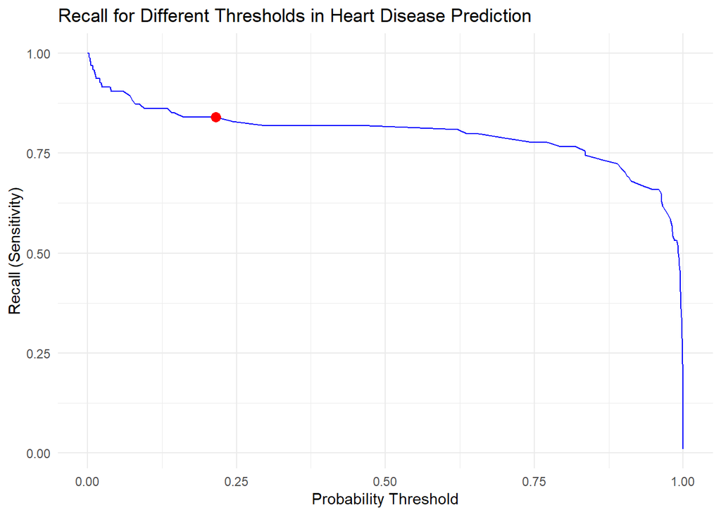

```r
# Plotting model sensitivity depending on probability threshold
# Create a data frame for plotting
recall_data <- data.frame(
  Threshold = roc_result$thresholds,
  Recall = roc_result$sensitivities
)

# Subset to only include thresholds between 0 and 1
recall_data <- subset(recall_data, Threshold >= 0 & Threshold <= 1)

# Find the optimal index and threshold
optimal_index <- which.max(roc_result$sensitivities + roc_result$specificities - 1)
optimal_threshold <- roc_result$thresholds[optimal_index]
optimal_recall <- roc_result$sensitivities[optimal_index]


# Plotting recall against probability threshold levels
ggplot(recall_data, aes(x = Threshold, y = Recall)) +
  geom_line(color = "blue") +
  geom_point(aes(x = optimal_threshold, y = optimal_recall), color = "red", size = 3) +
  labs(
    title = "Recall for Different Thresholds in Heart Disease Prediction",
    x = "Probability Threshold",
    y = "Recall (Sensitivity)"
  ) +
  theme_minimal()
```

```r
# Find the optimal index and corresponding threshold, sensitivity, and specificity
optimal_index <- which.max(roc_result$sensitivities + roc_result$specificities - 1)
optimal_threshold <- roc_result$thresholds[optimal_index]
optimal_sensitivity <- roc_result$sensitivities[optimal_index]
optimal_specificity <- roc_result$specificities[optimal_index]

# Print out the optimal coordinates
cat("Optimal Threshold:", optimal_threshold, "\n")
```

```
## Optimal Threshold: 0.2155241
```

```r
cat("Optimal Sensitivity (Recall):", optimal_sensitivity, "\n")
```

```
## Optimal Sensitivity (Recall): 0.8404255
```

```r
cat("Optimal Specificity:", optimal_specificity, "\n")
```

```
## Optimal Specificity: 0.8709677
```

Logistic Regression is a statistical method used for binary classification problems. Despite its name, it is used for classification rather than regression. Logistic Regression models the probability of an instance belonging to a particular class using the logistic function. It produces an output between 0 and 1, representing the probability of the instance belonging to the positive class. Logistic Regression is widely used due to its simplicity, interpretability, and efficiency. It can be extended to handle multi-class classification problems through techniques like one-vs-rest or softmax regression. Some of the main assumptions:

- Large sample size
- Absence of Outliers
- No Multicollinearity

```r
# Create the logistic model
logistic_model <- glm(Y_train ~ ., data = X_train, family = binomial)

# Use the model on the test dataset
Y_pred <- predict(logistic_model, newdata = X_test, type = "response")

# Convert predicted probabilities to class labels (0 or 1)
Y_pred <- ifelse(Y_pred > 0.5, 1, 0)

# Get confusion matrix
conf_matrix <- table(Actual = Y_pred, Predicted = Y_test)
print("Confusion Matrix:")
```

```
## [1] "Confusion Matrix:"
```

```r
print(conf_matrix)
```

```
##       Predicted
## Actual  0  1
##      0 82 16
##      1 11 78
```

```r
# Get classification report
class_report <- confusionMatrix(conf_matrix)

# Get model's performance
cat("\nAccuracy:", class_report$overall['Accuracy'], "\n")
```

```
##
## Accuracy: 0.855615
```

```r
cat("Precision:", class_report$byClass['Pos Pred Value'], "\n")
```

```
## Precision: 0.8367347
```

```r
cat("Recall (Sensitivity):", class_report$byClass['Sensitivity'], "\n")
```

```
## Recall (Sensitivity): 0.8817204
```

```r
cat("Specificity:", class_report$byClass['Specificity'], "\n")
```

```
## Specificity: 0.8297872
```

```r
y_pred_prob <- predict(logistic_model, newdata = X_test, type="response")

# Calculate AUC
roc_result <- roc(Y_test, y_pred_prob)
```

```r
auc_value <- auc(roc_result)

# Print AUC
cat("AUC (Area Under the ROC Curve):", auc_value, "\n")
```

```
## AUC (Area Under the ROC Curve): 0.9167239
```

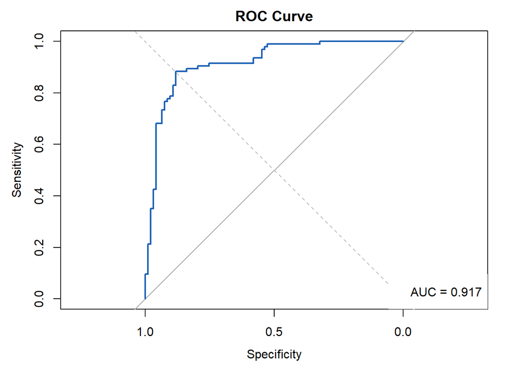

```r
plot(roc_result, main="ROC Curve", col="#1c61b6", lwd=2)
abline(a=0, b=1, lty=2, col="gray")
# Adds a diagonal dashed line representing a no-discrimination classifier

# Optionally, you can add the AUC value to the plot
auc_value <- auc(roc_result)
legend("bottomright", legend=paste("AUC =", round(auc_value, 3)), box.lty=0)
```

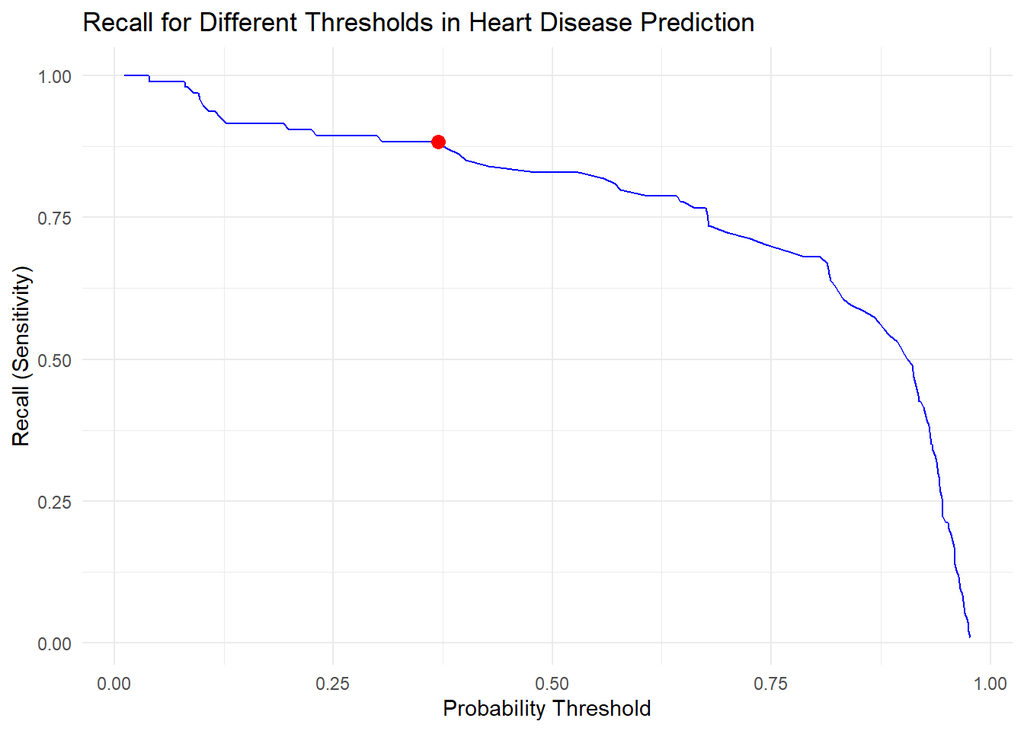

```r
# Plotting model sensitivity depending on probability threshold
# Create a data frame for plotting
recall_data <- data.frame(
  Threshold = roc_result$thresholds,
  Recall = roc_result$sensitivities
)

# Subset to only include thresholds between 0 and 1
recall_data <- subset(recall_data, Threshold >= 0 & Threshold <= 1)

# Find the optimal index and threshold
optimal_index <- which.max(roc_result$sensitivities + roc_result$specificities - 1)
optimal_threshold <- roc_result$thresholds[optimal_index]
optimal_recall <- roc_result$sensitivities[optimal_index]


# Plotting recall against probability threshold levels
ggplot(recall_data, aes(x = Threshold, y = Recall)) +
  geom_line(color = "blue") +
  geom_point(aes(x = optimal_threshold, y = optimal_recall), color = "red", size = 3) +
  labs(
    title = "Recall for Different Thresholds in Heart Disease Prediction",
    x = "Probability Threshold",
    y = "Recall (Sensitivity)"
  ) +
  theme_minimal()
```

```r
# Find the optimal index and corresponding threshold, sensitivity, and specificity
optimal_index <- which.max(roc_result$sensitivities + roc_result$specificities - 1)
optimal_threshold <- roc_result$thresholds[optimal_index]
optimal_sensitivity <- roc_result$sensitivities[optimal_index]
optimal_specificity <- roc_result$specificities[optimal_index]

# Print out the optimal coordinates
cat("Optimal Threshold:", optimal_threshold, "\n")
```

```
## Optimal Threshold: 0.3693672
```

```r
cat("Optimal Sensitivity (Recall):", optimal_sensitivity, "\n")
```

```
## Optimal Sensitivity (Recall): 0.8829787
```

```r
cat("Optimal Specificity:", optimal_specificity, "\n")
```

```
## Optimal Specificity: 0.8817204
```

Summary table

```r
# Create a data frame with the provided values rounded to 4 decimals
summary_table <- data.frame(
  Model = c("LDA", "QDA", "Naive Bayes", "Logistic Regression"),
  Accuracy = round(c(0.8609626, 0.855615, 0.8502674, 0.855615), 4),
  Precision = round(c(0.8817204, 0.8602151, 0.8817204, 0.8367347), 4),
  Recall = round(c(0.8453608, 0.8510638, 0.8282828, 0.8817204), 4),
  Specificity = round(c(0.8777778, 0.8602151, 0.875, 0.8297872), 4),
  AUC = round(c(0.9200412, 0.8882407, 0.9051704, 0.9167239), 4)
)

# Print the summary table using the kable and knitr packages
kable(summary_table, format = "html", align = "c") %>%
  kable_styling(full_width = FALSE, position = "center") %>%
  column_spec(2:6, width = "2em")
```

| Model | Accuracy | Precision | Recall | Specificity | AUC |
| --- | --- | --- | --- | --- | --- |
| LDA | 0.8610 | 0.8817 | 0.8454 | 0.8778 | 0.9200 |
| QDA | 0.8556 | 0.8602 | 0.8511 | 0.8602 | 0.8882 |
| Naive Bayes | 0.8503 | 0.8817 | 0.8283 | 0.8750 | 0.9052 |
| Logistic Regression | 0.8556 | 0.8367 | 0.8817 | 0.8298 | 0.9167 |

Sumamry table 2

```r
data <- data.frame(
  Model = c("LDA", "QDA", "Naive Bayes", "Logistic"),
  `Optimal Threshold` = round(c(0.3288703, 0.5984044, 0.2155241, 0.3693672), 4),
  `Optimal Sensitivity (Recall)` = round(c(0.893617, 0.8404255, 0.8404255, 0.8829787), 4),
  `Optimal Specificity` = round(c(0.8602151, 0.8709677, 0.8709677, 0.8817204), 4)
)

# Print the summary table using the kable and knitr packages
kable(data, format = "html", align = "c") %>%
  kable_styling(full_width = FALSE, position = "center") %>%
  column_spec(2:4, width = "2em")
```

| Model | Optimal.Threshold | Optimal.Sensitivity..Recall. | Optimal.Specificity |
| --- | --- | --- | --- |
| LDA | 0.3289 | 0.8936 | 0.8602 |
| QDA | 0.5984 | 0.8404 | 0.8710 |
| Naive Bayes | 0.2155 | 0.8404 | 0.8710 |
| Logistic | 0.3694 | 0.8830 | 0.8817 |